# Relatório

Fagner Gomes

1 - é possível acompanhar o crescimento do gêneros ou da música em si!?

R- em busca de tentar acompanha a evolução dos gêneros musicais (mais listados), é possível notar que entre 1920 e 1950 música não era algo tão produtivo, talvez pelo fato de rádio não ser tão popular, ou até mesmo período de guerra / crise.

> Gráfico para melhor visualização entre os anos 1920 e 1990

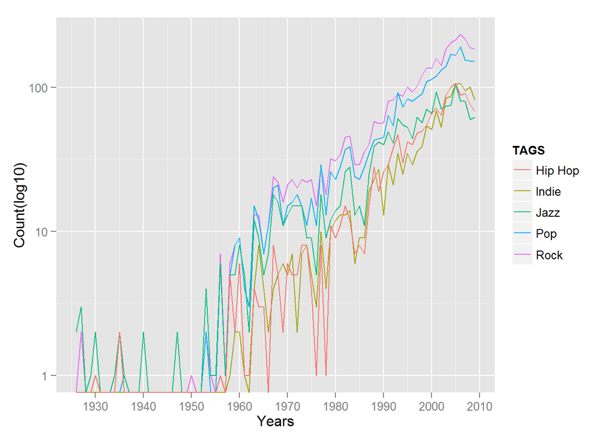

> Gráfico para melhor visualização após 1990

Porém, após esse período a música começa a se popularizar, entrando na era Disco Época em que era comum sair para se divertir a noite e escoltar alguma música de seu interesse. Com a revolução digital, surgimento do CD, o ramo musical começa a decolar, onde apresenta uma crescimento jamais visto.

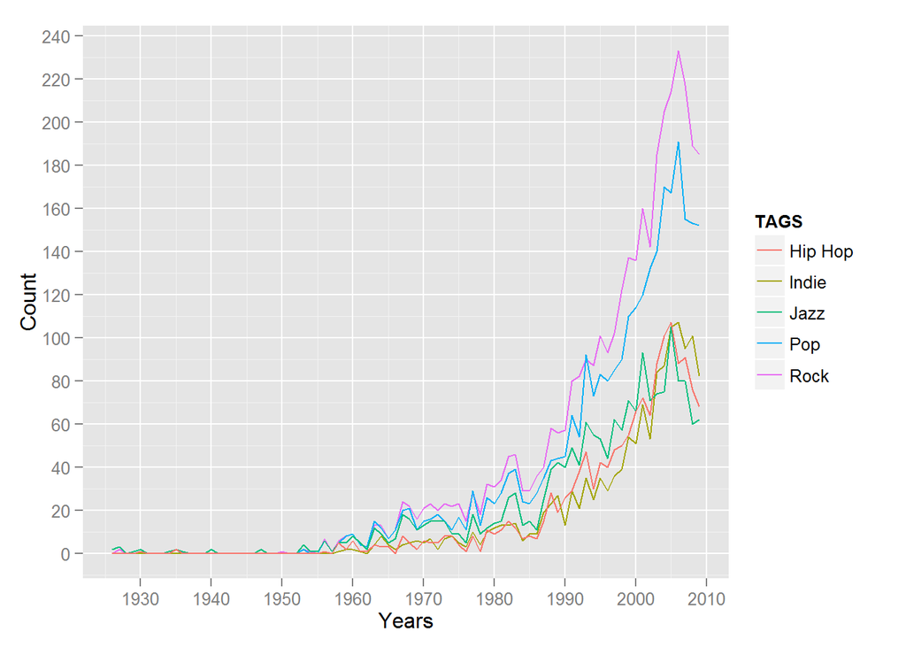

2 – Se um álbum for listado com mais de uma música, é possível determinar se a popularidade das músicas são semelhantes?

R- Como é possível observar no gráfico em Boxpot, a familiaridade de um álbum não é completamente distribuída, onde temos picos extremos tanto superiores como inferiores

> Relação entre Album e Familiaridade

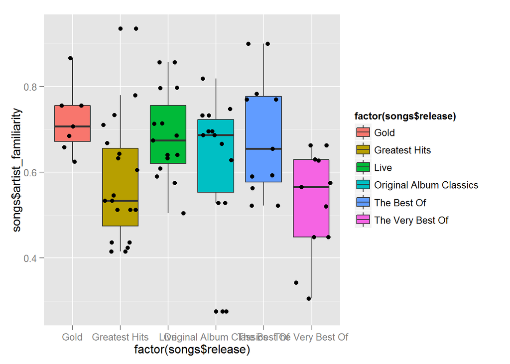

Se compararmos o Hotness com a familiaridade temos uma variação de valores menores encontrado, porém ainda é impossível afirmar que um álbum influencia a popularidade de suas músicas, sempre existirá a(s) musica(s) favorita(s)

> Relação entre Album e Popularidade(hotness)

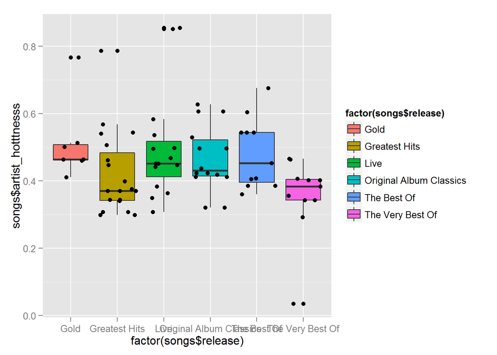